# Preregistration: Evaluation of Clinical Benefit

Author

Gaylen Fronk

Published

May 7, 2024

**Quick Links**

Jump to Section 3.2 for written modeling specifications.

Jump to Section 5 for analysis code.

## 1 Study Overview

### 1.1 Specific Aims

This project represents a tangible application of the precision mental health paradigm using modern machine learning approaches. This project aims to produce a decision-making tool to select among cigarette smoking cessation treatments for individuals looking to quit smoking.

Specifically, this project pursues the following aims:

**AIM 1:** Build a machine learning model to guide treatment selection for cigarette smoking cessation.

**AIM 2:** Evaluate the clinical benefit of using a treatment selection machine learning model.

### 1.2 Data

This project relies on existing data from a completed comparative effectiveness trial by [Baker et al., 2016](https://www.ncbi.nlm.nih.gov/pmc/articles/PMC4824537/).

Briefly, 1086 individuals who smoke cigarettes were randomized to receive varenicline, combination nicotine replacement therapy (NRT), or nicotine patch to assist with a quit attempt. Individuals were richly characterized at baseline (pre-treatment) with respect to demographic characteristics, mental health, social/environmental variables, physical health, and smoking history. Participants were assessed periodically for biologically confirmed, 7-day point-prevalence abstinence. When abstinence was biologically confirmed (i.e., via exhaled carbon monoxide), individuals were labeled as abstinent; otherwise, individuals were labeled as smoking.

Thus, we used predictors from the rich baseline characterization to predict our **primary outcome** of 7-day point-prevalence abstinence at 4 weeks post-quit.

## 2 Analysis Progress at Time of Preregistration

### 2.1 Completed: Model Building, Selection, & Evaluation

**AIM 1** analyses have been completed: Models using all available data have been fit and selected with nested cross-validation (1 repeat of 10-fold cross-validation in the inner loops, 3 repeats of 10-fold cross-validation in the outer loop). These 30-held out folds (“test sets”) were used to evaluate model performance. Models were evaluated using our primary performance metric, area under the ROC curve (auROC), an index of how well our models discriminate between positive (abstinent) and negative (smoking) cases.

We evaluated model performance in-depth by conducting *Bayesian hierarchical generalized linear models* to estimate the posterior probability distributions and 95% Bayesian credible intervals (CIs) for auROC for our best models from the 30 held-out test sets from nested cross-validation. Below, you can see the posterior probabilities for auROC in held-out folds.

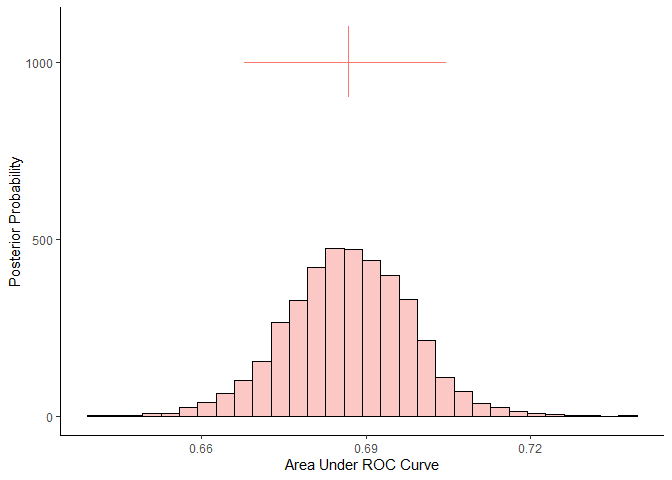

Figure 1

Source: Posterior probabilities across models for MATCH study (version v5)

The horizontal line indicates the 95% CIs. The vertical line represents the median posterior probability for auROC. This represents our best estimate for the magnitude of the auROC parameter. The CI does not contain 0.5 (i.e., chance performance), suggesting the model is capturing signal in the data.

### 2.2 Completed: Fit Final Model

A single, best model was selected with 1 repeat of 10-fold cross-validation in the full dataset. The best model configuration includes the following:

```
Rows: 1
Columns: 5
$ algorithm   <chr> "glmnet"
$ feature_set <chr> "item_ordinal"
$ alpha       <dbl> 0.1
$ lambda      <dbl> 0.1326421
$ resample    <chr> "up_1"
```

- Algorithm was glmnet (elastic net logistic regression)
- Selected feature set was “item_ordinal” indicating that individual items (rather than scale scores) were used, and ordinal scoring was used for ordered data (rather than dummy coding)
- Selected resampling approach was “up_1” corresponding to upsampling (vs. downsampling or SMOTE) with a ratio of 1:1 (majority:minority class)
- Values of the hyperparameters alpha and lambda were selected from sensible ranges for each value

### 2.3 In Progress: AIM 2 Clinical Benefit Analyses

**AIM 2** analyses using this full model are underway. We have used the final model fit in the full dataset to calculate three predictions (probabilities, `prob_*`) for each participant by substituting each treatment into the model inputs. Thus, there is one prediction per person per treatment.

| subid | prob_patch | prob_combo_nrt | prob_varenicline |
| --- | --- | --- | --- |
| 40244 | 0.430 | 0.531 | 0.570 |
| 51235 | 0.189 | 0.198 | 0.159 |
| 50478 | 0.436 | 0.319 | 0.403 |
| 40482 | 0.247 | 0.222 | 0.257 |
| 30048 | 0.583 | 0.542 | 0.561 |
| 30294 | 0.339 | 0.315 | 0.340 |
| 31221 | 0.192 | 0.153 | 0.217 |
| 50676 | 0.148 | 0.169 | 0.140 |

The treatment that yields the highest model-predicted probability of abstinence is identified as that participant’s “best” treatment (`tx_best`).

| subid | tx_best | prob_patch | prob_combo_nrt | prob_varenicline |
| --- | --- | --- | --- | --- |
| 50666 | varenicline | 0.159 | 0.185 | 0.189 |
| 50224 | varenicline | 0.193 | 0.165 | 0.207 |
| 50422 | combo_nrt | 0.344 | 0.352 | 0.246 |
| 30984 | combo_nrt | 0.195 | 0.227 | 0.197 |
| 50295 | patch | 0.455 | 0.431 | 0.437 |
| 20769 | varenicline | 0.450 | 0.516 | 0.569 |
| 51261 | patch | 0.357 | 0.340 | 0.305 |
| 30149 | combo_nrt | 0.443 | 0.465 | 0.341 |

The best treatments spanned all three medication options: varenicline, combination nicotine replacement therapy (“combo_nrt”), and nicotine patch (“patch”).

```
# A tibble: 3 × 3
  tx_best         n  prop
  <chr>       <int> <dbl>
1 combo_nrt     339 0.312
2 patch         193 0.178
3 varenicline   554 0.510
```

Some participants’ best treatment (`tx_best`) matched what they were randomly assigned in the original trial (`tx_rct`). Other participants may have received what the model identified as their second-best or worst treatment. Thus, participants’ RCT-assigned treatment can be categorized by whether it “matched” their model-assigned treatment (`tx_match`).

| subid | tx_match | tx_rct | tx_best | tx_second | tx_worst |
| --- | --- | --- | --- | --- | --- |
| 40645 | TRUE | varenicline | varenicline | patch | combo_nrt |
| 20015 | FALSE | combo_nrt | varenicline | combo_nrt | patch |
| 40126 | TRUE | combo_nrt | combo_nrt | varenicline | patch |
| 51165 | TRUE | varenicline | varenicline | patch | combo_nrt |
| 30705 | FALSE | combo_nrt | patch | varenicline | combo_nrt |
| 30179 | TRUE | patch | patch | combo_nrt | varenicline |
| 51390 | TRUE | varenicline | varenicline | patch | combo_nrt |
| 51817 | FALSE | patch | varenicline | combo_nrt | patch |

Approximately 38% of participants received their model-assigned “best” treatment in the original trial.

```
# A tibble: 2 × 3
  tx_match     n  prop
  <lgl>    <int> <dbl>
1 FALSE      677 0.623
2 TRUE       409 0.377
```

At the time of this preregistration, **no analyses have been conducted using these probabilities or model-based treatment assignments.**

## 3 Purpose of Preregistration

The purpose of this document is to **preregister the analyses for evaluating the clinical benefit of this treatment selection model**.

### 3.1 Outcomes

Our primary analysis will compare the **observed outcomes** (i.e., abstinence vs. smoking, from the original trial) for people who did or did not receive their best treatment. We will examine these outcomes over the following time points:

- 4 weeks: This served as the outcome for our prediction model. This selection was made so that, in real-world implementation, treatment could be adjusted earlier for individuals for whom treatment is not working.
- 12 weeks: This is end-of-treatment and represents a mid-point between the early (4-week) and later (26-week) outcomes.
- 26 weeks (6 months): This is the gold standard assessment period for smoking cessation treatments and was the primary outcome for the original trial ([Baker et al., 2016](https://www.ncbi.nlm.nih.gov/pmc/articles/PMC4824537/)). This duration is often used as a proxy for long-term success.

### 3.2 Modeling Specifications

We plan to follow a mixed-effects modeling approach using the `blme` package. Specifically, we will fit a partially Bayesian generalized linear model using `bglmer()` with the components listed below. This approach uses regularizing priors to force the estimated random effects variance-covariance matrices away from singularity ([Chung et al., 2013](https://link.springer.com/article/10.1007/s11336-013-9328-2), `blme` package). We would use the default `"nlminbwrap"` optimizer.

Our model will have the following components:

1. Dependent variable: abstinence (vs. smoking; `outcome_rct_num`). Binary outcome with abstinence coded as 1 and smoking coded as 0.
2. Independent variable: treatment match (`tx_match`). Between-subjects categorical variable with two levels (TRUE, 0.5; or FALSE, -0.5) such that we compare individuals who received their best treatment to individuals who did not.

```
# A tibble: 2 × 3
  tx_match     n  prop
     <dbl> <int> <dbl>
1     -0.5   677 0.623
2      0.5   409 0.377
```

3. Independent variable: time (`week`). This variable has repeated measures such that there are three time points for each subject. This variable will be treated as a numeric variable, and it will be log-transformed (natural log, base *e*) to meet linearity assumptions. Log transformation is appropriate when the shape of the relationship between the raw variable and outcome is asymptotic.

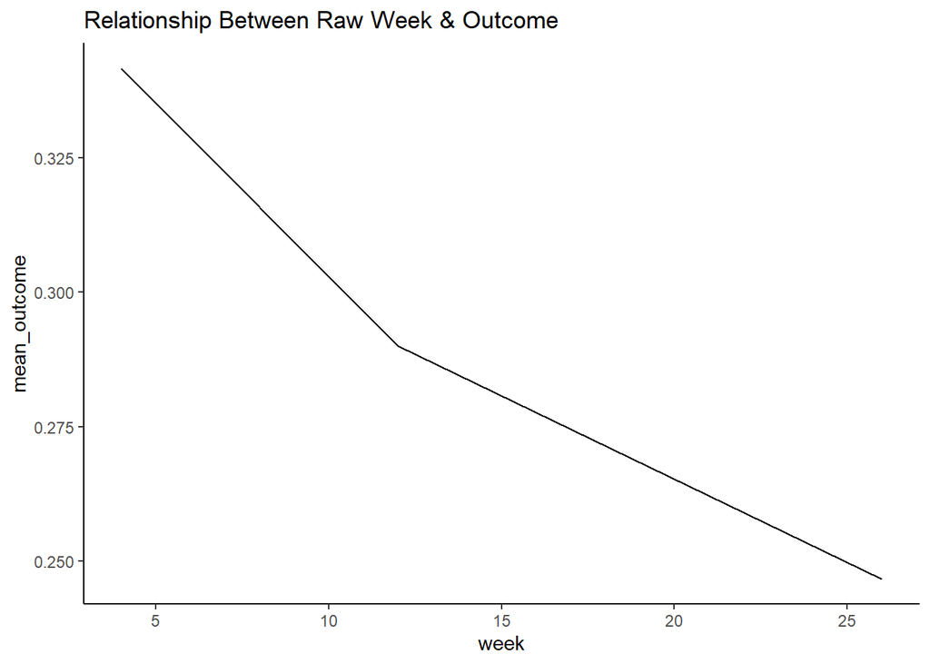

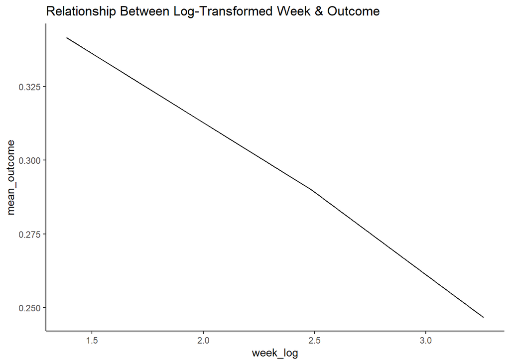

```
# A tibble: 3 × 4
# Groups:   week [3]
   week week_log     n  prop
  <dbl>    <dbl> <int> <dbl>
1     4     1.39  1086     1
2    12     2.48  1086     1
3    26     3.26  1086     1
```

4. Interaction between treatment match and time
5. Random slope for time (3 repeated observations of time for each subject)
6. Random intercept

### 3.3 Focal & Secondary Effects

Our **focal effect** is the effect of treatment match. We predict that individuals who received their best treatment will have improved outcomes compared to individuals who did not.

Our **secondary effect** is the interaction between treatment match and time. We do not have a directional hypothesis about this interaction.

- If this interaction is significant (*p* < 0.05), we will conduct **follow-up tests** of the simple effect of treatment match at all 3 time points (week 4, week 12, and week 26). These will be general linear models using the `glm` function within the `stats` package.

We plan to report the parameter estimates, test statistics, *p*-values, and confidence intervals for all effects from this model.

## 4 Shuffle Data

Typically, the above delineation is sufficient for preregistration. However, to ensure that all proposed analyses are feasible and to specify analyses as precisely as possible, **we conduct these proposed analyses using a shuffled (i.e., randomized) version of our dataset**. Following preregistration, our analyses will follow this script exactly using our real data.

To create our shuffled dataset, we randomly sample (without replacement) the treatment match (`tx_match`) variable. This:

- Breaks any relationship between `tx_match` and the outcome
- Breaks any interactive effect of `tx_match` and `week` on the outcome
- Maintains the random effect structure within the `week` variable

## 5 Preregistered Analyses

### 5.1 Primary Model

```r
model_bayes <- blme::bglmer(outcome_rct_num ~ tx_match * week_log +
                              (1 + week_log | subid),
                            data = d_shuf,
                            family = binomial(link = "logit"),
                            control = glmerControl(optCtrl = list(maxfun = 3e6)))

summary(model_bayes)$coefficients
```

```
                    Estimate Std. Error     z value     Pr(>|z|)
(Intercept)        1.9482148  0.3556276   5.4782441 4.295674e-08
tx_match          -0.3386496  0.4027471  -0.8408492 4.004324e-01
week_log          -2.2342858  0.2220852 -10.0604916 8.258496e-24
tx_match:week_log  0.1243824  0.2782697   0.4469852 6.548857e-01
```

### 5.2 Follow-up analyses: Simple Effects

If the interaction between `tx_match` and `week` is significant (*p* < 0.05), we will conduct follow-up analyses to test the simple effect of `tx_match` at each time point.

Simple effect at 4 weeks

```r
d_4_shuf <- d_shuf |>
  filter(week == 4)

model_4wk <- glm(outcome_rct_num ~ tx_match,
                 data = d_4_shuf,
                 family = binomial(link = "logit"))

summary(model_4wk)$coefficients
```

```
               Estimate Std. Error     z value     Pr(>|z|)
(Intercept) -0.66653320 0.06626066 -10.0592604 8.362419e-24
tx_match    -0.08264026 0.13252131  -0.6235997 5.328905e-01
```

Simple effect at 12 weeks

```r
d_12_shuf <- d_shuf |>
  filter(week == 12)

model_12wk <- glm(outcome_rct_num ~ tx_match,
                  data = d_12_shuf,
                  family = binomial(link = "logit"))

summary(model_12wk)$coefficients
```

```
                Estimate Std. Error      z value     Pr(>|z|)
(Intercept) -0.894255020 0.06897945 -12.96407887 1.955655e-38
tx_match     0.006995181 0.13795890   0.05070482 9.595607e-01
```

Simple effect at 26 weeks

```r
d_26_shuf <- d_shuf |>
  filter(week == 26)

model_26wk <- glm(outcome_rct_num ~ tx_match,
                  data = d_26_shuf,
                  family = binomial(link = "logit"))

summary(model_26wk)$coefficients
```

```
               Estimate Std. Error     z value     Pr(>|z|)
(Intercept) -1.11061763 0.07244033 -15.3314818 4.711156e-53
tx_match     0.04352304 0.14488066   0.3004061 7.638674e-01
```